# Lecture8_Tidyverse

Kelly and Gallego

Remember that swirling ocean of code that people create and contribute to an open-source software package like **R**? Yeah… sometimes it can get pretty chaotic. In fact – as in the development of spoken languages – there can be competing styles, regional inconsistencies, and so on. And occasionally, you get a new dialect that buds off into what could become its own language. Today we’re talking about the “tidyverse”, which is sort of a dialect within the universe of **R**, and it’s increasingly common, so you should know about it.

###History

There is this guy, [Hadley Wickham](http://hadley.nz/).

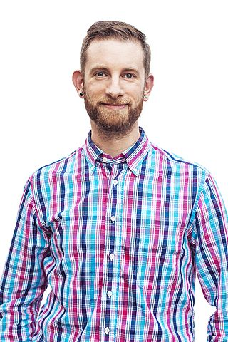

He is the central deity of the universe that includes **RStudio** (where he works as Chief Scientist), and the collection of **R** packages that he has developed (“tidyr”, “dplyr”, etc), which are collectively known as the “Tidyverse”. You can now get all of these packages together: `install.packages("tidyverse")`. There are loads of his talks on [YouTube](https://www.google.com/search?q=youtube+hadley+wickham), in case you want to watch talks about **R** in your free time.

He seems to have done some of this work during the course of his PhD at Iowa State University; the fact that a grad student has had such an enormous impact on the world of statistical computing is pretty darn cool. The New York Times and many other media outlets use ggplot2 for graphics, for example; Hadley is one of its creators and also wrote the book on ggplot2.

#The Idea

In New Zealandish, “tidy” means “neat” or “orderly”. And so, a tidy dataset is one that is neat, orderly, and ready to be analyzed and visualized. [You might be familiar with Hadley’s peer-reviewed [paper](http://vita.had.co.nz/papers/tidy-data.html) in the *Journal of Statistical Software* on tidy data. But then again, you may not be familiar with it.]

Let’s work through the “tidyr” vignette on tidy data.

(The vignette gives great examples and works through tidying messy data… look at it in detail)

The take-home here is that:

- What matters in a dataset is the collection of **values**
- Every value belongs to a **variable** (which we put in columns, one to a column, such that essentially a variable == a column) and an **observation** (which we put in rows)
- The key is to define your variables carefully and efficiently. You should never have results in your column headers; only the names of the variables being recorded with each observation. (See “Column headers are values, not variable names”, in the vignette).

A side-effect of this view of the universe is, because all of the information we need is contained within the values themselves and the names of the variables for which those values are data, *we don’t need row names*.

#Inputting Information and Piping

Remember calculators? They were the first kinds of computers that non-super-nerds used all the time, and could carry around easily. Different kinds of calculators exposed really interesting questions about how people should interact with machines. In particular, should a user enter information in the way that the user thinks about it (== the way that a mathematical operation is written on paper, for example), or in the way that the computer thinks about it (which is often more efficient)?<sup>1</sup>

<sup>1. [The way you write math on paper – for example, `1 + 1` is called “infix notation”, because the *operator* (= function, in this case “add”) is in the middle of the two values it is supposed to work on (in case you’re interested, these are the *operands*.) And when you think about it, this is a weird way to express anything; the most important bit is an infix between two variables. It’s the equivalent of “noun verb noun” … which is how English works (“Mary greets Jane”), but not really how machines probably work. An alternative, “postfix notation” was the way the world’s first scientific calculator, the HP-35 (https://en.wikipedia.org/wiki/HP-35) worked. It required the user to first enter the values on which the machine would work, and *then* the function (= operator). So, instead of `1 + 1`, the user would enter `1, 1, +` (This is also called “Reverse Polish Notation”, and is more efficient in general, reducing the number of keystrokes necessary for calculation). Apparently, engineers loved this.] ↩</sup>

In any case… the same kinds of questions about how to most logically put information into a computer are evident in **R**.

Regular, base **R** does things with the function *first*, and then the operand. (I suppose this is “prefix notation”). `sum( c(1,1) )`. And in the case of simple mathematical operators, they include a special option to use infix option `1 + 1`. Which is fine.

But… often we want to do a string of operations all in a row. For example, we want to take the number of prisoners booked in Seattle jails and then group them by courthouse and then take a mean and a variance of the amount of time they were in jail. Or do the same thing, but with flight times from New York. If we do all of these operations separately, we have to store all of the intermediate products along the way, and we don’t really care about these products. They take up space, clutter the desktop, and make it hard to follow your own code later (or to follow anyone else’s code).

Computers solve this problem by “piping”… doing one operation, and passing the result onto the next operation, and so on. Base **R** doesn’t have piping, so Hadley and others created a way to do it. The result is a kind of postfix notation: you pass a value to a function, and then get a result.

The pipe is represented as `%>%`, and it works like this: `value %>% function()` , or `noun %>% verb` . By contrast, as you know, base **R** works like this: `function(value)`.

```r
# Base R
sum(c(1, 1))
```

```
## [1] 2
```

```r
# tidyR
c(1, 1) %>% sum()
```

```
## [1] 2
```

This looks ugly with just one operation to do. But it shines when you’ve got a series of them.

```r
c(1:10)  %>%         #take a vector of numbers and send it down the line...
  sqrt() %>%         #take the square root of each number in the vector, and send it...
  keep(.< 3)  %>%    #keep only the values that are under 3, and send it...
  sum()              #sum the resulting numbers)
```

```
## [1] 16.306
```

```r
#the equivalent in baseR is:

a <- c(1:10)
b <- sqrt(a)
d <- b[b<3]
sum(d)
```

```
## [1] 16.306
```

```r
#for which we had to store three intermediate sets of values we didn't actually care about. And which probably took longer.
```

So, let’s compare different ways of doing things, and practice piping. We’ll perform a set of operations the base-**R** way, and then do it the tidyverse way.

Let’s say we want to calculate the top 10 names of the 20th century for babies born in the US, and then plot the frequency of those names over time. And (this is a gender-binary dataset) perhaps we’ll do it for babies identified as male and female, respectively.

```r
baby <- read.csv("../Data/NationalNames.csv")  #national baby names; 1.8 million records between 1880 and 2014
```

# Base **R**

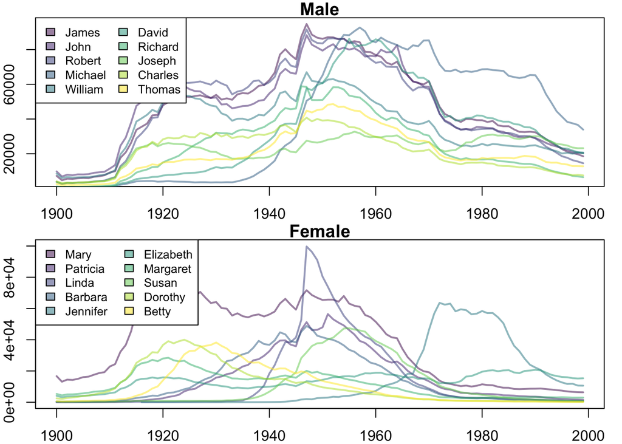

```r
# Base R

starttime <- Sys.time()  #record time the calculation started, for comparison

baby20th <- baby[baby$Year >= 1900 & baby$Year <= 1999, ]  #trim dataset to just 20th century

babyTotal <- aggregate(baby20th$Count, by = list(baby20th$Name, baby20th$Gender),
    FUN = sum)  #aggregate all instances of each name by summing across all years in the dataset
names(babyTotal) <- c("Name", "Gender", "TotalCount")  #rename, for legibility

babyTotal <- babyTotal[order(babyTotal$TotalCount, decreasing = T), ]  #sort on decreasing total counts

# grab the top 10 most-common names for M- and F-assigned babies
top10male <- as.character(babyTotal$Name[babyTotal$Gender == "M"][1:10])
top10female <- as.character(babyTotal$Name[babyTotal$Gender == "F"][1:10])

# now go back to the original dataset, and plot these names through time

library(viridis)
colorScheme <- viridis(10, alpha = 0.5)

par(mfrow = c(2, 1))  #create canvas with two plots
par(mar = c(2, 2, 1, 1))  #change margins

# plot top-10 males
plot(Count ~ Year, data = baby20th[baby20th$Name == top10male[1] & baby20th$Gender ==
    "M", ], type = "l", lwd = 2, col = colorScheme[1], main = "Male")  #set up the plot with the most common name
for (i in 2:10) {
    # run a loop to add the others
    points(Count ~ Year, data = baby20th[baby20th$Name == top10male[i] & baby20th$Gender ==
        "M", ], type = "l", lwd = 2, col = colorScheme[i])
}
legend("topleft", legend = top10male, fill = colorScheme, ncol = 2, cex = 0.8)  #add a legend

# plot top-10 females
plot(Count ~ Year, data = baby20th[baby20th$Name == top10female[1] & baby20th$Gender ==
    "F", ], type = "l", lwd = 2, ylim = c(0, 1e+05), col = colorScheme[1], main = "Female")  #set up the plot with the most common name
for (i in 2:10) {
    # run a loop to add the others
    points(Count ~ Year, data = baby20th[baby20th$Name == top10female[i] & baby20th$Gender ==
        "F", ], type = "l", lwd = 2, col = colorScheme[i])
}
legend("topleft", legend = top10female, fill = colorScheme, ncol = 2, cex = 0.8)  #add a legend
```

```r
endtime <- Sys.time()

# elapsed time in seconds
endtime - starttime
```

```
## Time difference of 12.70287 secs
```

# Tidyverse

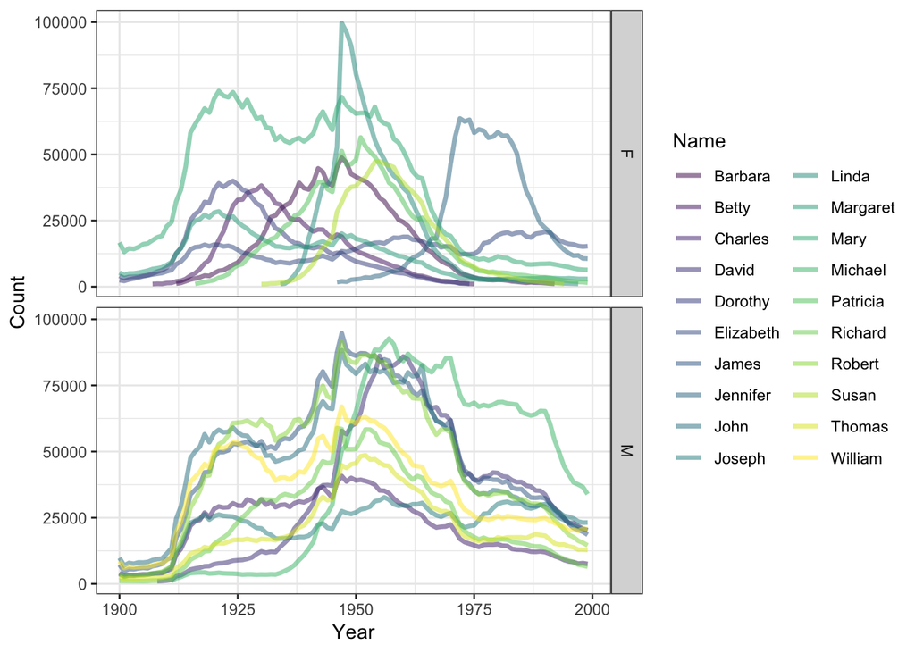

```r
starttime <- Sys.time()  #record time the calculation started, for comparison

baby %>%   #take the baby df, and ...
  filter(Year >= 1900 & Year <= 1999) %>%   #filter for the appropriate years
  group_by(Name, Gender) %>% #group by name and gender
  summarize(TotalCount = sum(Count)) %>%  #aggregate by name and gender by summing Counts to create a new variable, TotalCount
  arrange(desc(TotalCount)) %>%  #arrange the resulting table by TotalCount in descending order
  group_by(Gender) %>%  #group by gender, and...
  top_n(10) -> #take the top 10 of each gender.... and create a new object w the result, called top10s
  top10s

#now plot these over time
colorScheme <- viridis(20, alpha = 0.5)

baby %>%
  filter(Year >= 1900 & Year <= 1999) %>%   #filter for the appropriate years
  filter(Name%in%top10s$Name) %>%   #filter for top10 names in each gender
  filter(Count > 1000) %>%  #clear out underbrush to focus on trends, and pipe to ggplot
    ggplot(aes(x = Year, y = Count, color = Name)) +
      geom_line(size = 1.2) +
      facet_grid(Gender~.) +
      scale_color_manual(values=colorScheme) +
      guides(color=guide_legend(ncol=2)) +
      theme_bw()
```

```r
endtime <- Sys.time()

#elapsed time in seconds
endtime - starttime
```

```
## Time difference of 3.71277 secs
```

So, let’s note some things here:

- The tidyverse is considerably faster and involves considerably less code
- Piping makes things easier to follow, and can flow right into graphing with ggplot
- The pipe `%>%` isn’t the only difference w the tidyverse; there are many functions that are specific to the tidyverse, and these often have underscores (e.g., `group_by`), although not necessarily (`filter`, `arrange`, etc).
- The tidyverse often lets you skip quotation marks around the names of columns/variables
- Piping your functions often makes you re-think how to organize things; we don’t just use the regular base-**R** functions in the middle of a series of pipes (although this is often possible)
- By default, the pipe sends data into the next command as the FIRST argument of that command; sometimes, however, you may need to use the character `.` in a piping command to specify otherwise. For example `facet_grid(Gender~.)` says that you are going to use the piped data in place of the `.` rather than as the first argument.
- `group_by` and `summarize` are extremely useful ways of subsetting data and applying functions to the different subsets… without a `for` loop. We will focus on these more in the coming weeks, but for now, know that `group_by` tells **R** which variables you are going to want to use as categories (on which to perform some operation), and then `summarize` performs some operation on the data, but does it for each group separately. [see https://dplyr.tidyverse.org/ for more.]

For example:

```r
library(yarrr)

pirates %>% #pirates dataset from yarrr package
  group_by(sword.type) %>%  #group data by sword type, and then ...
  summarize(mean(grogg))    #take the mean of column `grogg` for pirates having each sword type
```

```
## # A tibble: 4 x 2
##   sword.type `mean(grogg)`
##   <chr>              <dbl>
## 1 banana              10.3
## 2 cutlass             10.1
## 3 sabre               10.3
## 4 scimitar            10.4
```

```r
#this is equivalent to:

for (i in unique(pirates$sword.type)){
  print(
    mean(
      pirates$grogg[pirates$sword.type==i]
    )
  )
}
```

```
## [1] 10.10843
## [1] 10.38596
## [1] 10.31343
## [1] 10.26087
```

```r
#and also equivalent to:

sapply(unique(pirates$sword.type),
       function(x) {mean(
                        pirates$grogg[pirates$sword.type==x])
         }
       )
```

```
##  cutlass scimitar    sabre   banana
## 10.10843 10.38596 10.31343 10.26087
```

# Finally

Recall that tidy data often uses long tables (with few columns or “variables”, but many rows or “cases/observations”). You may want/need to reshape your datasets to make good use of some tidyverse/ggplot commands. This means you will often use `gather` and `spread`. We will cover these in the coming weeks, along with the base-**R** commands `aggregate` and `split`.